# Bayesian Inference: Model Comparison Example

PHYS5513

September 9, 2025

# Bayesian Inference: Determining the Source of an Observation

## Problem Statement

We have two possible data generating processes: 1. **Model 1 (M₁)**: Uniform distribution U(0,1) 2. **Model 2 (M₂)**: Gaussian distribution N(μ, σ²)

We observe a value **x = 0.93** and want to determine: *What is the probability that this observation came from each distribution?*

## Theoretical Foundation

### Bayes’ Theorem for Model Comparison

For model comparison, we use Bayes’ theorem:

$$P(M_i|x) = \frac{P(x|M_i) \cdot
P(M_i)}{P(x)}$$

Where: - $P(M_i|x)$ = **Posterior probability** of model $M_i$ given observation $x$ - $P(x|M_i)$ = **Likelihood** of observing $x$ under model $M_i$ - $P(M_i)$ = **Prior probability** of model $M_i$ (before seeing data) - $P(x)$ = **Evidence** (normalization constant)

### The Evidence (Denominator)

The evidence is the total probability of observing $x$:

$$P(x) = \sum_{i} P(x|M_i) \cdot
P(M_i)$$

For our two-model case:

$$P(x) = P(x|M_1) \cdot P(M_1) + P(x|M_2)
\cdot P(M_2)$$

### Computing Relative Probabilities

The ratio of posterior probabilities (Bayes factor × prior ratio):

$$\frac{P(M_1|x)}{P(M_2|x)} =
\frac{P(x|M_1)}{P(x|M_2)} \cdot \frac{P(M_1)}{P(M_2)}$$

## Step-by-Step Derivation

### Step 1: Define the Likelihoods

For **Model 1** (Uniform U(0,1)):
$$P(x|M_1) = \begin{cases}
1 & \text{if } 0 \leq x \leq 1 \\
0 & \text{otherwise}
\end{cases}$$

For our observation $x = 0.93$: $P(0.93|M_1) = 1$

For **Model 2** (Gaussian N(μ, σ²)):
$$P(x|M_2) = \frac{1}{\sqrt{2\pi\sigma^2}}
\exp\left(-\frac{(x-\mu)^2}{2\sigma^2}\right)$$

### Step 2: Specify Priors

We’ll assume **equal priors**: $P(M_1) = P(M_2) = 0.5$

This means we have no initial preference for either model.

### Step 3: Calculate Posteriors

$$P(M_1|x) = \frac{P(x|M_1) \cdot
P(M_1)}{P(x|M_1) \cdot P(M_1) + P(x|M_2) \cdot P(M_2)}$$

$$P(M_2|x) = \frac{P(x|M_2) \cdot
P(M_2)}{P(x|M_1) \cdot P(M_1) + P(x|M_2) \cdot P(M_2)}$$

## Implementation

```r
# Define our observation
x_obs <- 0.93

# Model 1: Uniform distribution U(0,1)
likelihood_uniform <- function(x) {
  ifelse(x >= 0 & x <= 1, 1, 0)
}

# Model 2: Gaussian distribution N(mu, sigma^2)
# We need to specify parameters for the Gaussian
mu <- 0.5    # mean
sigma <- 0.2 # standard deviation

likelihood_gaussian <- function(x, mu, sigma) {
  dnorm(x, mean = mu, sd = sigma)
}

# Calculate likelihoods for our observation
L1 <- likelihood_uniform(x_obs)
L2 <- likelihood_gaussian(x_obs, mu, sigma)

cat("Likelihood under Uniform model:", L1, "\n")
```

```
## Likelihood under Uniform model: 1
```

```r
cat("Likelihood under Gaussian model:", L2, "\n")
```

```
## Likelihood under Gaussian model: 0.1977502
```

```r
# Prior probabilities (equal priors)
prior_M1 <- 0.5
prior_M2 <- 0.5

# Calculate evidence (normalization constant)
evidence <- L1 * prior_M1 + L2 * prior_M2

# Calculate posterior probabilities
posterior_M1 <- (L1 * prior_M1) / evidence
posterior_M2 <- (L2 * prior_M2) / evidence

cat("\nPosterior Probabilities:\n")
```

```
##
## Posterior Probabilities:
```

```r
cat("P(Uniform | x = 0.93) =", round(posterior_M1, 4), "\n")
```

```
## P(Uniform | x = 0.93) = 0.8349
```

```r
cat("P(Gaussian | x = 0.93) =", round(posterior_M2, 4), "\n")
```

```
## P(Gaussian | x = 0.93) = 0.1651
```

```r
# Bayes factor
bayes_factor <- L1 / L2
cat("\nBayes Factor (Uniform vs Gaussian):", round(bayes_factor, 4), "\n")
```

```
##
## Bayes Factor (Uniform vs Gaussian): 5.0569
```

## Visualization

Let’s visualize both distributions and see where our observation falls:

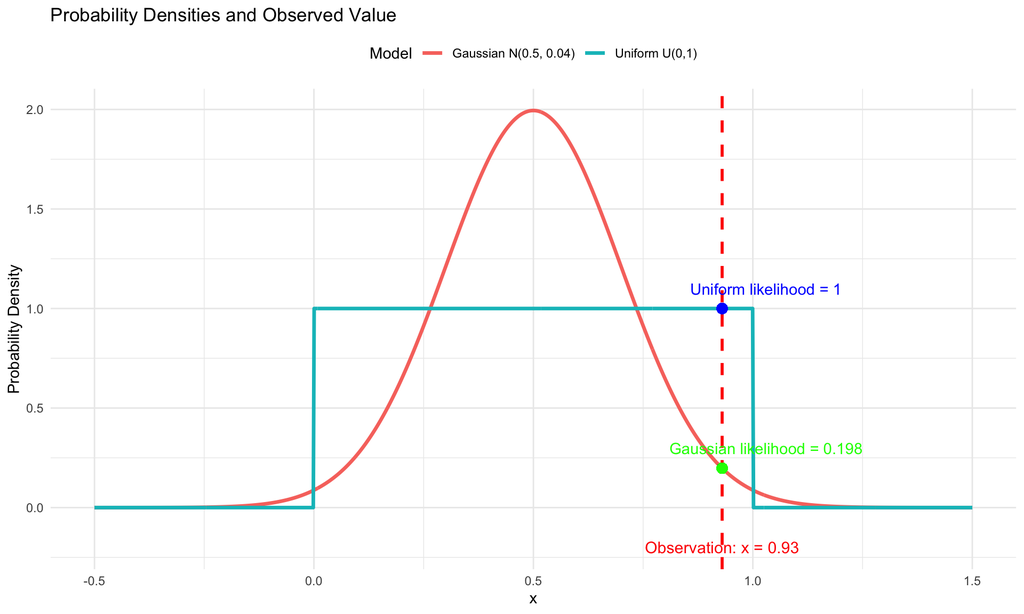

```r
# Create a range of x values
x_range <- seq(-0.5, 1.5, length.out = 1000)

# Calculate densities
uniform_density <- sapply(x_range, likelihood_uniform)
gaussian_density <- sapply(x_range, function(x) likelihood_gaussian(x, mu, sigma))

# Create data frame for plotting
plot_data <- data.frame(
  x = rep(x_range, 2),
  density = c(uniform_density, gaussian_density),
  model = rep(c("Uniform U(0,1)", paste0("Gaussian N(", mu, ", ", sigma^2, ")")),
              each = length(x_range))
)

# Create the plot
p1 <- ggplot(plot_data, aes(x = x, y = density, color = model)) +
  geom_line(size = 1.2) +
  geom_vline(xintercept = x_obs, linetype = "dashed", color = "red", size = 1) +
  geom_point(x = x_obs, y = L1, color = "blue", size = 3) +
  geom_point(x = x_obs, y = L2, color = "green", size = 3) +
  annotate("text", x = x_obs + 0.1, y = L1 + 0.1,
           label = paste("Uniform likelihood =", round(L1, 3)),
           color = "blue") +
  annotate("text", x = x_obs + 0.1, y = L2 + 0.1,
           label = paste("Gaussian likelihood =", round(L2, 3)),
           color = "green") +
  annotate("text", x = x_obs, y = -0.2,
           label = paste("Observation: x =", x_obs),
           color = "red", size = 4) +
  labs(title = "Probability Densities and Observed Value",
       x = "x", y = "Probability Density",
       color = "Model") +
  theme_minimal() +
  theme(legend.position = "top")

print(p1)
```

## Posterior Probability Visualization

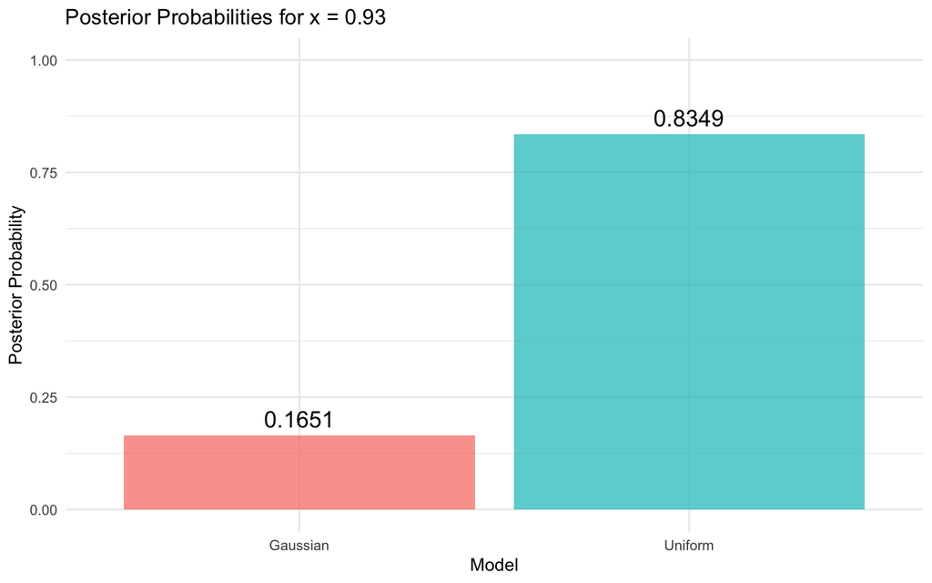

```r
# Create bar plot of posterior probabilities
posterior_data <- data.frame(
  Model = c("Uniform", "Gaussian"),
  Posterior = c(posterior_M1, posterior_M2)
)

p2 <- ggplot(posterior_data, aes(x = Model, y = Posterior, fill = Model)) +
  geom_bar(stat = "identity", alpha = 0.7) +
  geom_text(aes(label = round(Posterior, 4)), vjust = -0.5, size = 5) +
  labs(title = paste("Posterior Probabilities for x =", x_obs),
       y = "Posterior Probability") +
  theme_minimal() +
  theme(legend.position = "none") +
  ylim(0, 1)

print(p2)
```

## Sensitivity Analysis: Effect of Gaussian Parameters

Let’s see how the posterior probabilities change with different Gaussian parameters:

```r
# Test different Gaussian parameters
mu_values <- c(0.3, 0.5, 0.7, 0.9)
sigma_values <- c(0.1, 0.2, 0.3, 0.4)

results <- expand.grid(mu = mu_values, sigma = sigma_values)
results$posterior_uniform <- NA
results$posterior_gaussian <- NA

for (i in 1:nrow(results)) {
  mu_test <- results$mu[i]
  sigma_test <- results$sigma[i]

  L1_test <- likelihood_uniform(x_obs)
  L2_test <- likelihood_gaussian(x_obs, mu_test, sigma_test)

  evidence_test <- L1_test * prior_M1 + L2_test * prior_M2

  results$posterior_uniform[i] <- (L1_test * prior_M1) / evidence_test
  results$posterior_gaussian[i] <- (L2_test * prior_M2) / evidence_test
}

print("Sensitivity Analysis Results:")
```

```
## [1] "Sensitivity Analysis Results:"
```

```r
print(results)
```

```
##     mu sigma posterior_uniform posterior_gaussian
## 1  0.3   0.1         1.0000000       9.601433e-09
## 2  0.5   0.1         0.9996148       3.852035e-04
## 3  0.7   0.1         0.7792590       2.207410e-01
## 4  0.9   0.1         0.2077327       7.922673e-01
## 5  0.3   0.2         0.9862212       1.377878e-02
## 6  0.5   0.2         0.8348986       1.651014e-01
## 7  0.7   0.2         0.4926882       5.073118e-01
## 8  0.9   0.2         0.3364289       6.635711e-01
## 9  0.3   0.3         0.8721346       1.278654e-01
## 10 0.5   0.3         0.6774741       3.225259e-01
## 11 0.7   0.3         0.5022136       4.977864e-01
## 12 0.9   0.3         0.4304454       5.695546e-01
## 13 0.3   0.4         0.7760789       2.239211e-01
## 14 0.5   0.4         0.6411733       3.588267e-01
## 15 0.7   0.4         0.5418916       4.581084e-01
## 16 0.9   0.4         0.5013651       4.986349e-01
```

## Key Insights

1. **The observation x = 0.93 is quite extreme** for most reasonable Gaussian distributions centered around 0.5.
2. **The uniform distribution assigns equal probability** to all values in [0,1], so it doesn’t “prefer” any particular value.
3. **The Gaussian distribution’s likelihood depends heavily on how close the observation is to its mean** and how large its variance is.
4. **Bayes factors provide evidence strength**:
   - BF > 3: Substantial evidence
   - BF > 10: Strong evidence
   - BF > 30: Very strong evidence

## Mathematical Summary

For our specific case with x = 0.93:

$$P(\text{Uniform}|x) = \frac{1 \times
0.5}{1 \times 0.5 + P(x|N(\mu,\sigma^2)) \times 0.5}$$

$$P(\text{Gaussian}|x) =
\frac{P(x|N(\mu,\sigma^2)) \times 0.5}{1 \times 0.5 +
P(x|N(\mu,\sigma^2)) \times 0.5}$$

The key insight is that **the uniform distribution doesn’t penalize extreme values**, while **the Gaussian distribution does** (unless the observation is close to its mean).

## Extension: Multiple Observations

Let’s see what happens with multiple observations:

```r
# Simulate multiple observations
set.seed(123)
n_obs <- 10
observations <- c(0.93, 0.85, 0.76, 0.88, 0.91, 0.82, 0.79, 0.86, 0.89, 0.84)

# Calculate joint likelihood (assuming independence)
joint_likelihood_uniform <- prod(sapply(observations, likelihood_uniform))
joint_likelihood_gaussian <- prod(sapply(observations, function(x)
  likelihood_gaussian(x, mu, sigma)))

# Calculate posterior probabilities
evidence_joint <- joint_likelihood_uniform * prior_M1 +
                  joint_likelihood_gaussian * prior_M2

posterior_uniform_joint <- (joint_likelihood_uniform * prior_M1) / evidence_joint
posterior_gaussian_joint <- (joint_likelihood_gaussian * prior_M2) / evidence_joint

cat("Multiple Observations Analysis:\n")
```

```
## Multiple Observations Analysis:
```

```r
cat("Observations:", paste(observations, collapse = ", "), "\n")
```

```
## Observations: 0.93, 0.85, 0.76, 0.88, 0.91, 0.82, 0.79, 0.86, 0.89, 0.84
```

```r
cat("P(Uniform | data) =", round(posterior_uniform_joint, 6), "\n")
```

```
## P(Uniform | data) = 0.999875
```

```r
cat("P(Gaussian | data) =", round(posterior_gaussian_joint, 6), "\n")
```

```
## P(Gaussian | data) = 0.000125
```

```r
# Calculate log Bayes factor to avoid numerical issues
log_bayes_factor <- sum(log(sapply(observations, likelihood_uniform))) -
                   sum(log(sapply(observations, function(x)
                     likelihood_gaussian(x, mu, sigma))))

cat("Log Bayes Factor =", round(log_bayes_factor, 4), "\n")
```

```
## Log Bayes Factor = 8.9863
```

This example demonstrates the power of Bayesian inference for model comparison and how evidence accumulates with multiple observations!